# Topic 26

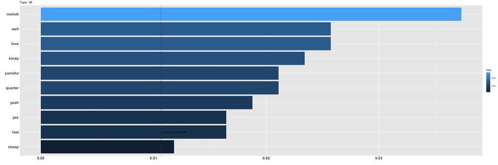

On interpreting beta: the term has a beta probability of being generated from the particular topic.

Values below are gamma : An estimated proportion of words from that document that are generated from that topic.

**Text Record Number: 175** gamma: 11 % likelihood of this document (based on its words) in this topic

**It’s good enough from a theoretical point of view, but I won’t say it could help reaching an “advanced” level. All those lessons, even the “advanced” ones, seem kinda basic to me. They can get you the basics, but if you want more “advanced” stuff you’ll need a proper method or, better, a teacher.**

**Text Record Number: 355** gamma: 11 % likelihood of this document (based on its words) in this topic

**The finger number is a good indicator but I don’t really agree with all of them, as they are marking by professionals who may have a bigger hand size or more finger flexibility than you. Your teacher, if competent should tell you the fingering for a particular piece tailored to how you like it. I have small hands and my teacher give me personal finger suggestions all the time.**

**Text Record Number: 636** gamma: 11 % likelihood of this document (based on its words) in this topic

**We all learn pieces that are beyond our current ability in order to raise our bar, the trick is to balance that out with lots of more casual easier pieces.

Imagine only reading ONE SHAKESPEARE PLAY and NOTHING ELSE! No books, no magazines, no reddit, just the Shakespeare play until you had it memorized… that would suck… but that’s kinda what happens when we don’t balance a difficult piece of rep with lots of accessible casual stuff.**

**Text Record Number: 524** gamma: 11 % likelihood of this document (based on its words) in this topic

**So one thing you can do is learn how to “extend” your normal triads. The most common extension is the 7th. So learning your major 7th, minor 7th and dominant 7th chords will add a bit of flair. Also learning how to use your inversions of triads and 7th chords could lead to better voice leading.

Finally learning how to Embellish the melody by adding chord tones and harmonies to them would be another idea.**

**Text Record Number: 570** gamma: 11 % likelihood of this document (based on its words) in this topic

**They are a crutch that you will inevitably grow out of, and they can also reinforce some bad habits. The point of learning what all the keys are is so you *don’t* have to think about which key is which. Relying on stickers won’t reinforce that. Instead of looking at a blank key and thinking “which one is this? Oh yeah, it’s F”, you’ll just see a sticker that says “F”, there is no memory recall required. The brain remembers thing best when you have *just* started to forget whatever that information is, when you reintroduce that memory you’re basically telling your brain “hey, this is important information, remember it.” When you’re relying on stickers, this activity is much slower to develop, because you’ll have a constant reminder telling you which ones are which.

If you think about it there’s really only 12 notes you need to learn the positions of on a piano. 7 white keys and 4 black keys. These are repeated in the exact same pattern across all the octaves in the piano. So no matter where you go on the piano, you’ll still only have access to the same 12 notes. Once you get them memorized for one octave you’ve memorized them in every octave.**

**Text Record Number: 1438** gamma: 11 % likelihood of this document (based on its words) in this topic

**Hello everyone! I have decided to start my journey of seriously learning how to play the piano using music theory (Bought Alfred’s Book 1 to start) instead of memorizing youtube videos. I bought myself a cheap 61 key keyboard a while ago and it does not have weighted keys and playing it strongly or softly does not change how it sounds. Is not having all 88 notes and weighted keys going to hinder my progress and skills? Would it be worth it to spend a few hundred on a keyboard like the Yamaha P-45 or P-71 with 88 weighted keys or just stick to my current keyboard. If there are any better keyboards that this sub would recommend, I would be happy to hear about it! Thank you all.**

**Text Record Number: 402** gamma: 11 % likelihood of this document (based on its words) in this topic

**Someone once asked a famous jazz sax player, “ What goes through your mind before you solo?”

He answered, “Here we go.”

My point being that improvising is about being willing to let go of the editorial mind and just surrender to the music. You’d be amazed at the music that you can produce without thought.

You have to internalize music to the point that it becomes a language that you can speak without thinking about it. You don’t think about grammar when you talk. Just have fun in the discovery of new musical ‘words’ that resonate with you and use them until they become second nature. And listen. A lot.

Just my ten cents.**